# CalibrationPlot

Author

Sarah Urbut

Published

February 17, 2024

## **Step 1: Preparing the Data**

1. **Merge Predicted Risks with Actual Outcomes**: For each model’s predictions (PCE, ASCVD, states), you’ll need to ensure that you have a way to align each prediction with the actual outcome for the same individual at the same age. This may require reshaping or merging data frames.
2. **Handling Censored Data in `states` Predictions**: For individuals who have been censored at certain ages in the **`states`** data, you’ll need to decide on an approach. One common method is to exclude these individuals from the analysis for ages where they are censored since you don’t have predictions for them.

### **Step 2: Calculating Observed and Predicted Risks**

For each age from 40 to 70, and for each model:

- Calculate the mean predicted risk for that age.
- Calculate the observed rate of **`Cad_Any == 2`** within the individuals not censored at that age.

### **Step 3: Creating Calibration Plots**

You can create calibration plots by following these steps for each model:

1. **Bin Predicted Risks**: If your predictions span a continuous range, consider binning them into deciles or another suitable grouping. This step might be slightly different for the **`states`** data, depending on how risk is represented.
2. **Calculate Observed Rates by Bin**: For each bin, calculate the observed frequency of the outcome (**`Cad_Any == 2`**).
3. **Plotting**: Plot the mean predicted risk against the observed frequency for each bin. Repeat this for each age group or consider aggregating across age groups if appropriate.We have all of our predictions stored in a list

```r
states=readRDS("~/multistate2/output/state_occupancy_risk.rds")

library("ggsci")
library(dplyr)
library(tidyr)
library(data.table)
library(ggplot2)
library(ggpubr)

test=readRDS("~/multistate2/output/test.rds")
pce.reverse.tenyear=readRDS("~/multistate2/output/pce.reverse.tenyear.rds")
ascvd.30.year.rc=readRDS("~/multistate2/output/ascvd.30year.rcnew.rds")
states=readRDS("~/multistate2/output/state_occupancy_risk.rds")
df=test
df$Cad_0_censor_age=round(df$Cad_0_censor_age,0)
df$Cad_0_Any=ifelse(df$Cad_0_Any==2,1,0)
df$agecensor=as.numeric(difftime(df$censordateHES,df$Birthdate,units = "days")/365.25)

bad_indices=which(df$Cad_0_censor_age>=80&df$Cad_0_Any==1)



expanded_df <- data.frame()

score1_list=states
names(score1_list)=df$identifier
score2=ascvd.30.year.rc
rownames(score2)=df$identifier

score3=pce.reverse.tenyear
rownames(score3)=df$identifier

# # Removing the bad IDs from score1_list
score1_list <- score1_list[-bad_indices]
#
# # Removing the bad IDs from score2 dataframe
score2 <- score2[-bad_indices, ]
#
# # Removing the bad IDs from score2 dataframe
score3 <- score3[-bad_indices, ]


# exclude those with events after

df=df[-which(df$Cad_0_censor_age>=80&df$Cad_0_Any==1),]
dim(df)
```

```
[1] 78974    68
```

```r
all.equal(as.numeric(names(score1_list)),as.numeric(df$identifier))
```

```
[1] TRUE
```

```r
all.equal(as.numeric(rownames(score2)),as.numeric(df$identifier))
```

```
[1] TRUE
```

```r
all.equal(as.numeric(rownames(score3)),as.numeric(df$identifier))
```

```
[1] TRUE
```

```r
# Initialize a list to store the results
expanded_list <- vector("list", length = nrow(df))

for(i in 1:nrow(df)) {
  #print(i)
  id <- df$id[i]
  max_age <- df$Cad_0_censor_age[i]
  event <- df$Cad_0_Any[i]
   enroll = df$phenos.enrollment[i]

  # When max_age is less than 40 or length of score1_list[i] is 0
  if (max_age < 40 || length(score1_list[[i]]) == 0) {
    next  # Skip this iteration and proceed to the next
  }

  age_range <- 40:(40 + length(score1_list[[i]]) - 1)
  score1_values <- score1_list[[i]]
  score2_values <- score2[i, age_range - 39]
  score3_values <- score3[i, age_range - 39]

  # If there's an event and score1 is shorter than expected
  if (event == 1 && max(age_range) < max_age) {
    extended_age_range <- (max(age_range) + 1):max_age
    score1_last_value <- rep(tail(score1_list[[i]], 1), times = length(extended_age_range))
    score1_values <- c(score1_list[[i]], score1_last_value)
    score2_last_value <- score2[i,(extended_age_range-39)]
    score2_values <- c(score2_values, score2_last_value)
    score3_last_value <- score3[i,(extended_age_range-39)]
    score3_values <- c(score3_values, score3_last_value)
    age_range <- c(age_range, extended_age_range)
  }

  # Store the resulting dataframe as a list element
  expanded_list[[i]] <- data.frame(id = id,
                                   age = age_range,
                                   score1 = score1_values,
                                   score2 = score2_values,
                                   score3 = score3_values,
                                   enroll=enroll,
                                   event = ifelse(age_range == max_age, event, 0))
}



expanded_df <- do.call(rbind, expanded_list)
expanded_df$score1=expanded_df$score1*100
expanded_df$start <- expanded_df$age
expanded_df$stop <- expanded_df$age + 1


print(dim(expanded_df))
```

```
[1] 2206675       9
```

```r
# Determine if an event ever occurs for each individual
event_occurrence <- expanded_df %>%
  group_by(id) %>%
  summarise(event_ever = max(event)) # Assuming 'event' is 1 if it occurs, 0 otherwise





df_with_event <- expanded_df %>%
  left_join(event_occurrence, by = "id")

# # Determine if an event ever occurs for each individual
# ed=expanded_df[expanded_df$id%in%goodms,]

#event_occurrence <- ed %>%
#   group_by(id) %>%
#   summarise(event_ever = max(event)) # Assuming 'event' is 1 if it occurs, 0 otherwise
#
# df_with_event <- ed %>%
#   left_join(event_occurrence, by = "id")


calibration_plots_data <- df_with_event %>%
group_by(age) %>%
mutate(score1_bin = ntile(score1, 5)) %>%
group_by(age, score1_bin) %>%
summarise(mean_predicted = mean(score1),
          observed_rate = 100*mean(event_ever),error=sqrt(1/length(score1)*(mean(score1)/100)*(1-mean(score1)/100))) %>%ungroup()
```

[output not shown]

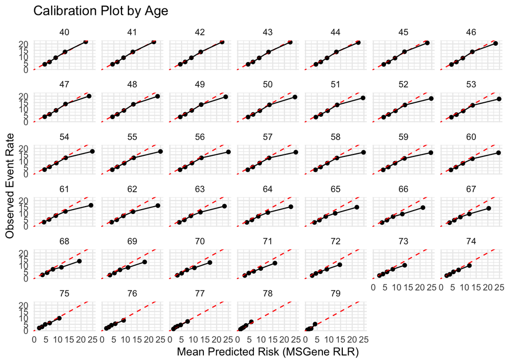

```r
ggplot(calibration_plots_data, aes(x = mean_predicted, y = observed_rate)) +
geom_point() +geom_abline(intercept = 0, slope = 1, linetype = "dashed", color = "red")+
geom_line() +
facet_wrap(~age) +
labs(title = "Calibration Plot by Age", x = "Mean Predicted Risk (MSGene RLR)", y = "Observed Event Rate") +
theme_minimal()
```

```r
### for FRS30

# Determine if an event ever occurs for each individual

calibration_plots_data <- df_with_event %>%
group_by(age) %>%
mutate(score2_bin = ntile(score2, 10)) %>%
group_by(age, score2_bin) %>%
summarise(mean_predicted = mean(score2),
          observed_rate = 100*mean(event_ever)) %>%ungroup()
```

[output not shown]

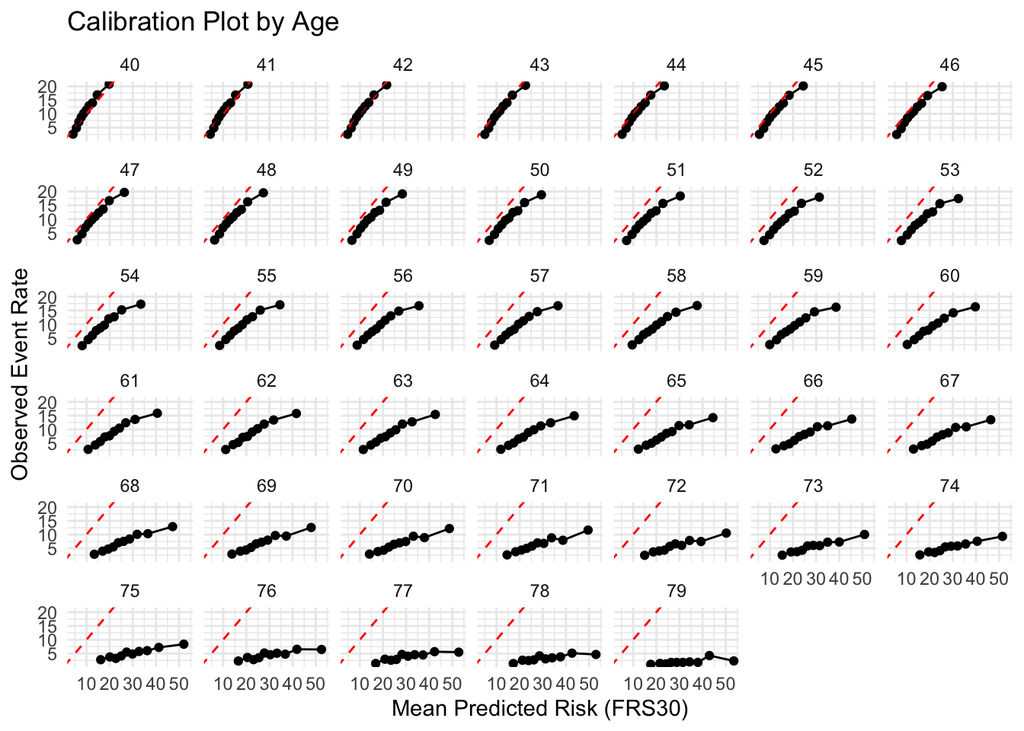

```r
ggplot(calibration_plots_data, aes(x = mean_predicted, y = observed_rate)) +
geom_point() +geom_abline(intercept = 0, slope = 1, linetype = "dashed", color = "red")+
geom_line() +
facet_wrap(~age) +
labs(title = "Calibration Plot by Age", x = "Mean Predicted Risk (FRS30)", y = "Observed Event Rate") +
theme_minimal()
```

Here we do it restricting MSGene to individuals who had the ability to be followed to 80:

```r
goodms=df$identifier[df$agecensor>79]

# # Determine if an event ever occurs for each individual
ed=expanded_df[expanded_df$id%in%goodms,]

event_occurrence <- ed %>%
group_by(id) %>%
summarise(event_ever = max(event)) # Assuming 'event' is 1 if it occurs, 0 otherwise
#
df_with_event <- ed %>%
left_join(event_occurrence, by = "id")


calibration_plots_data <- df_with_event %>%
group_by(age) %>%
mutate(score1_bin = ntile(score1, 5)) %>%
group_by(age, score1_bin) %>%
summarise(mean_predicted = mean(score1),
          observed_rate = 100*mean(event_ever),error=sqrt(1/length(score1)*(mean(score1)/100)*(1-mean(score1)/100))) %>%ungroup()
```

[output not shown]

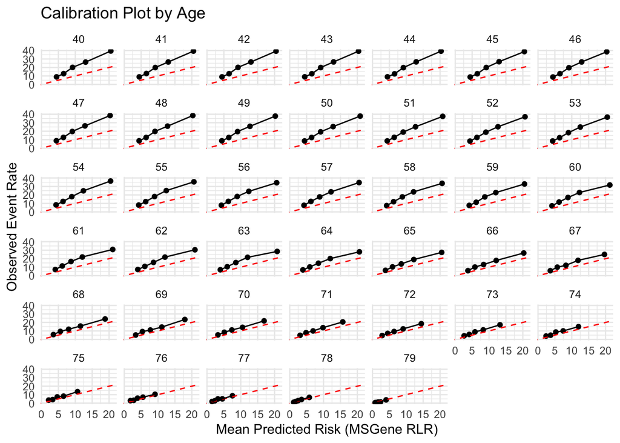

```r
ggplot(calibration_plots_data, aes(x = mean_predicted, y = observed_rate)) +
geom_point() +geom_abline(intercept = 0, slope = 1, linetype = "dashed", color = "red")+
geom_line() +
facet_wrap(~age) +
labs(title = "Calibration Plot by Age", x = "Mean Predicted Risk (MSGene RLR)", y = "Observed Event Rate") +
theme_minimal()
```

```r
test=readRDS("~/multistate2/output/test.rds")
pce.reverse.tenyear=readRDS("~/multistate2/output/pce.reverse.tenyear.rds")
ascvd.30.year.rc=readRDS("~/multistate2/output/ascvd.30year.rcnew.rds")
states=readRDS("~/multistate2/output/state_occupancy_risk_30.rds")
df=test
df$Cad_0_censor_age=round(df$Cad_0_censor_age,0)
df$Cad_0_Any=ifelse(df$Cad_0_Any==2,1,0)
df$agecensor=as.numeric(difftime(df$censordateHES,df$Birthdate,units = "days")/365.25)

goodms=df$identifier[df$agecensor>79]
bad_indices=which(df$Cad_0_censor_age>=80&df$Cad_0_Any==1)



expanded_df <- data.frame()

score1_list=states
names(score1_list)=df$identifier
score2=ascvd.30.year.rc
rownames(score2)=df$identifier

score3=pce.reverse.tenyear
rownames(score3)=df$identifier

# # Removing the bad IDs from score1_list
score1_list <- score1_list[-bad_indices]
#
# # Removing the bad IDs from score2 dataframe
score2 <- score2[-bad_indices, ]
#
# # Removing the bad IDs from score2 dataframe
score3 <- score3[-bad_indices, ]


# exclude those with events after

df=df[-which(df$Cad_0_censor_age>=80&df$Cad_0_Any==1),]
dim(df)
```

```
[1] 78974    68
```

```r
all.equal(as.numeric(names(score1_list)),as.numeric(df$identifier))
```

```
[1] TRUE
```

```r
all.equal(as.numeric(rownames(score2)),as.numeric(df$identifier))
```

```
[1] TRUE
```

```r
all.equal(as.numeric(rownames(score3)),as.numeric(df$identifier))
```

```
[1] TRUE
```

```r
# Initialize a list to store the results
expanded_list <- vector("list", length = nrow(df))

for(i in 1:nrow(df)) {
  #print(i)
  id <- df$id[i]
  max_age <- df$Cad_0_censor_age[i]
  event <- df$Cad_0_Any[i]
   enroll = df$phenos.enrollment[i]

  # When max_age is less than 40 or length of score1_list[i] is 0
  if (max_age < 40 || length(score1_list[[i]]) == 0) {
    next  # Skip this iteration and proceed to the next
  }

  age_range <- 40:(40 + length(score1_list[[i]]) - 1)
  score1_values <- score1_list[[i]]
  score2_values <- score2[i, age_range - 39]
  score3_values <- score3[i, age_range - 39]

  # If there's an event and score1 is shorter than expected
  if (event == 1 && max(age_range) < max_age) {
    extended_age_range <- (max(age_range) + 1):max_age
    score1_last_value <- rep(tail(score1_list[[i]], 1), times = length(extended_age_range))
    score1_values <- c(score1_list[[i]], score1_last_value)
    score2_last_value <- score2[i,(extended_age_range-39)]
    score2_values <- c(score2_values, score2_last_value)
    score3_last_value <- score3[i,(extended_age_range-39)]
    score3_values <- c(score3_values, score3_last_value)
    age_range <- c(age_range, extended_age_range)
  }

  # Store the resulting dataframe as a list element
  expanded_list[[i]] <- data.frame(id = id,
                                   age = age_range,
                                   score1 = score1_values,
                                   score2 = score2_values,
                                   score3 = score3_values,
                                   enroll=enroll,
                                   event = ifelse(age_range == max_age, event, 0))
}



expanded_df <- do.call(rbind, expanded_list)
expanded_df$score1=expanded_df$score1*100
expanded_df$start <- expanded_df$age
expanded_df$stop <- expanded_df$age + 1


print(dim(expanded_df))
```

```
[1] 2206675       9
```

```r
# Determine if an event ever occurs for each individual
event_occurrence <- expanded_df %>%
  group_by(id) %>%
  summarise(event_ever = max(event)) # Assuming 'event' is 1 if it occurs, 0 otherwise





df_with_event <- expanded_df %>%
  left_join(event_occurrence, by = "id")

# # Determine if an event ever occurs for each individual
# ed=expanded_df[expanded_df$id%in%goodms,]

#event_occurrence <- ed %>%
#   group_by(id) %>%
#   summarise(event_ever = max(event)) # Assuming 'event' is 1 if it occurs, 0 otherwise
#
# df_with_event <- ed %>%
#   left_join(event_occurrence, by = "id")


calibration_plots_data <- df_with_event %>%
group_by(age) %>%
mutate(score1_bin = ntile(score1, 20)) %>%
group_by(age, score1_bin) %>%
summarise(mean_predicted = mean(score1),
          observed_rate = 100*mean(event_ever)) %>%ungroup()
```

[output not shown]

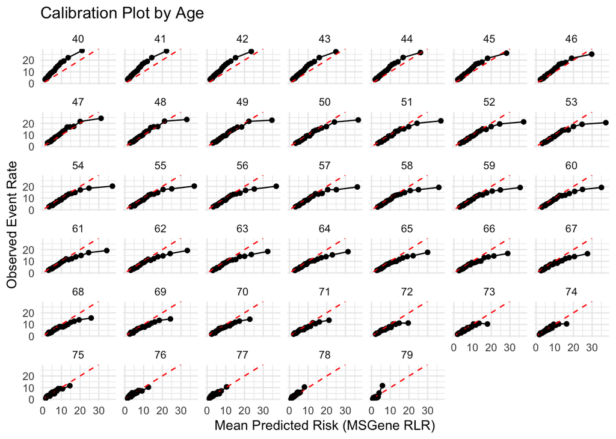

```r
ggplot(calibration_plots_data, aes(x = mean_predicted, y = observed_rate)) +
geom_point() +geom_abline(intercept = 0, slope = 1, linetype = "dashed", color = "red")+
geom_line() +
facet_wrap(~age) +
labs(title = "Calibration Plot by Age", x = "Mean Predicted Risk (MSGene RLR)", y = "Observed Event Rate") +
theme_minimal()
```

## here for means?

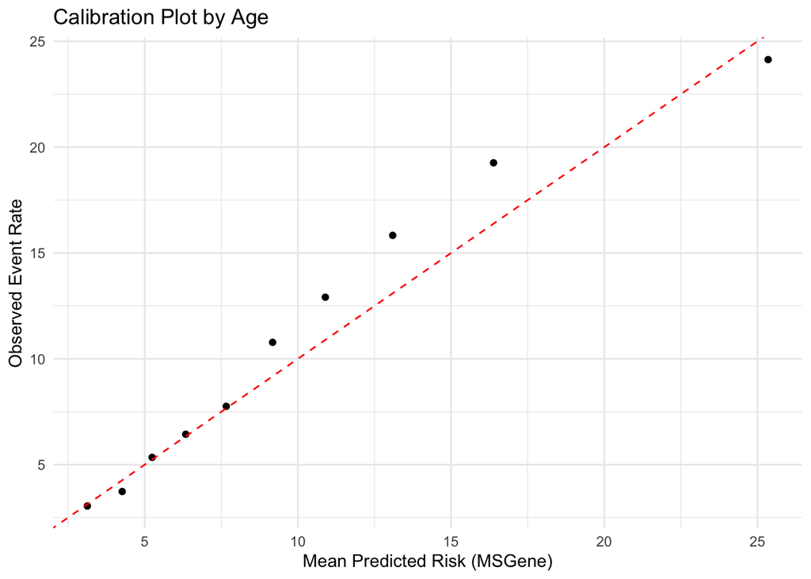

```r
meanex=expanded_df%>%group_by(id)%>%summarize(m1=mean(score1),m2=mean(score2),e=sum(event))


calibration_plots_data_ms <- meanex %>%
mutate(score1_bin = ntile(m1,10)) %>%
group_by(score1_bin) %>%summarise(mean_predicted = mean(m1),
observed_rate = 100*mean(e),l=length(m1))


ggplot(calibration_plots_data_ms, aes(x = mean_predicted, y = observed_rate)) +
geom_point() +geom_abline(intercept = 0, slope = 1, linetype = "dashed", color = "red")+labs(title = "Calibration Plot by Age", x = "Mean Predicted Risk (MSGene)", y = "Observed Event Rate") +theme_minimal()
```

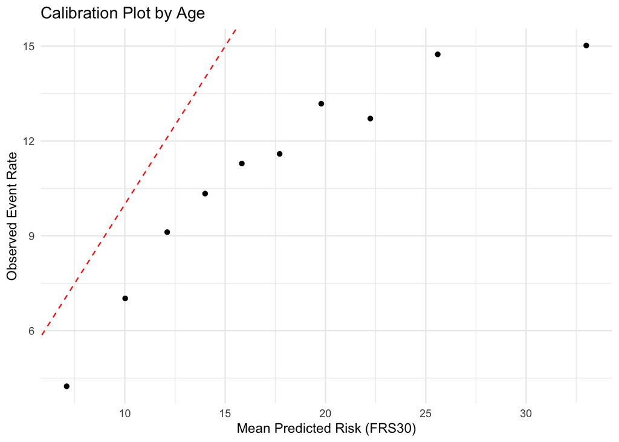

```r
###


calibration_plots_data_frs <- meanex %>%
mutate(score1_bin = ntile(m2,10)) %>%
group_by(score1_bin) %>%summarise(mean_predicted = mean(m2),
observed_rate = 100*mean(e),l=length(m2))

ggplot(calibration_plots_data_frs, aes(x = mean_predicted, y = observed_rate)) +
geom_point() +geom_abline(intercept = 0, slope = 1, linetype = "dashed", color = "red")+labs(title = "Calibration Plot by Age", x = "Mean Predicted Risk (FRS30)", y = "Observed Event Rate") +theme_minimal()
```

```r
library(survival)

# Create the survival object
surv_obj <- with(df_with_event, Surv(time = start, time2 = stop, event = event))

# Fit Cox models for each score
cox_model_score1 <- coxph(surv_obj ~ score1, data = df_with_event)
cox_model_score2 <- coxph(surv_obj ~ score2, data = df_with_event)


library(survival)

# Create the survival object
surv_obj <- with(df_with_event, Surv(time = start, time2 = stop, event = event))

# Fit Cox models for each score
cox_model_score1 <- coxph(surv_obj ~ score1, data = df_with_event)
cox_model_score2 <- coxph(surv_obj ~ score2, data = df_with_event)

# This is a conceptual approach; actual implementation will vary based on data and goals
# Assuming you have predicted probabilities and observed outcomes at 10 years

# Create deciles of predicted probabilities
df_with_event$score1_decile <- cut(df_with_event$predicted_prob_score1, breaks = quantile(df_with_event$predicted_prob_score1, probs = 0:10/10), include.lowest = TRUE)
df_with_event$score2_decile <- cut(df_with_event$predicted_prob_score2, breaks = quantile(df_with_event$predicted_prob_score2, probs = 0:10/10), include.lowest = TRUE)

# Calculate observed event rates by decile
observed_events_score1 <- aggregate(event ~ score1_decile, data = df_with_event, FUN = mean)
observed_events_score2 <- aggregate(event ~ score2_decile, data = df_with_event, FUN = mean)

# Plot observed vs. predicted for Score 1 and Score 2
library(ggplot2)

ggplot(observed_events_score1, aes(x = score1_decile, y = event)) +
  geom_point(aes(color = 'Score 1')) +
  geom_line(aes(color = 'Score 1')) +
  geom_point(data = observed_events_score2, aes(x = score2_decile, y = event, color = 'Score 2')) +
  geom_line(data = observed_events_score2, aes(x = score2_decile, y = event, color = 'Score 2')) +
  labs(x = 'Predicted Probability Decile', y = 'Observed Event Rate', title = 'Calibration Plot')
```

[output not shown]